# Sta112FS 15. Wrap up one var inf + Testing for independence

October 27, 2015

## Today's agenda

## Today's agenda

- Wrap up one variable inference
- Testing for independence
- Get started on App Ex 8

## Wrap up one variable inference

## Rent in Durham

Data from a random sample of 20 1+ bedroom apartments in Durham in 2012.

```r
durham_apts <- read.csv("https://stat.duke.edu/~mc301/data/durham_apts.csv")
```

## Exploratory analysis

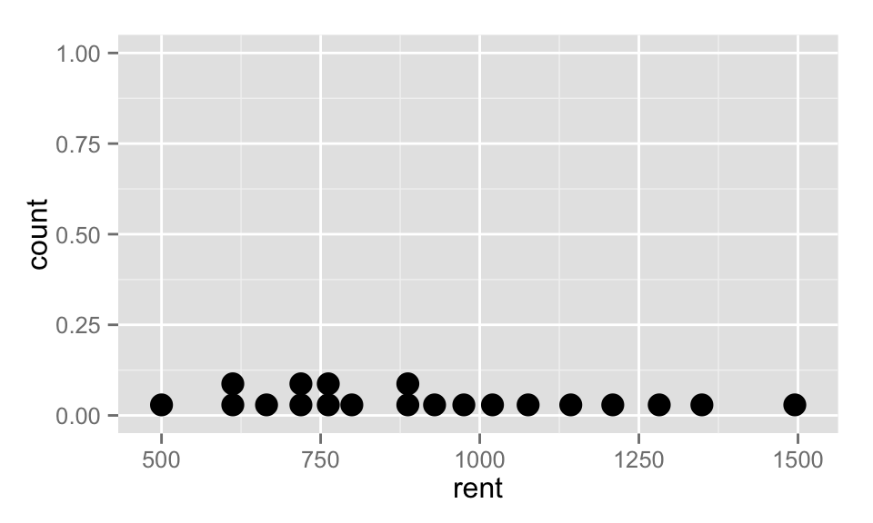

```r
ggplot(data = durham_apts, aes(x = rent)) +
  geom_dotplot()
```

```r
durham_apts %>%
  summarise(xbar = mean(rent), med = median(rent))
```

```
##    xbar med
## 1 920.1 887
```

## Load helper functions

```r
source("https://stat.duke.edu/courses/Fall15/sta112.01/code/one_num_boot.R")
source("https://stat.duke.edu/courses/Fall15/sta112.01/code/one_num_test.R")
```

## Bootstrap CI for mean rent in Durham

Estimate the average rent in Durham for 1+ bedroom apartments using a 95% confidence interval.

```r
one_num_boot(durham_apts$rent, statistic = mean, seed = 195729)
```

```
## Summary stats: n = 20, sample mean = 920.1
## 95% CI: (795.968, 1044.232)
```

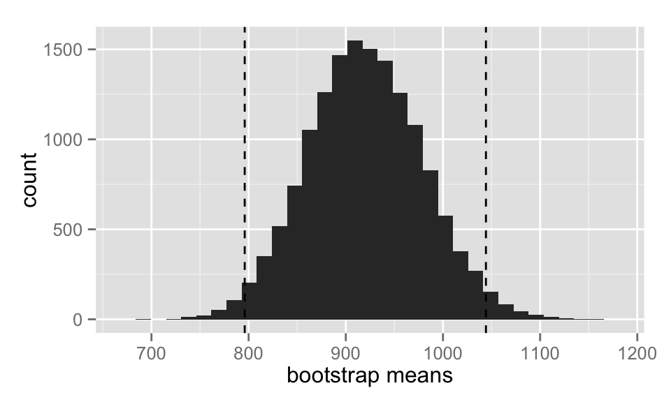

## Bootstrap CI for median rent in Durham

Estimate the median rent in Durham for 1+ bedroom apartments using a 95% confidence interval.

```r
one_num_boot(durham_apts$rent, statistic = median, seed = 571035)
```

```
## Summary stats: n = 20, sample median = 887
## 95% CI: (712.8174, 1061.1826)
```

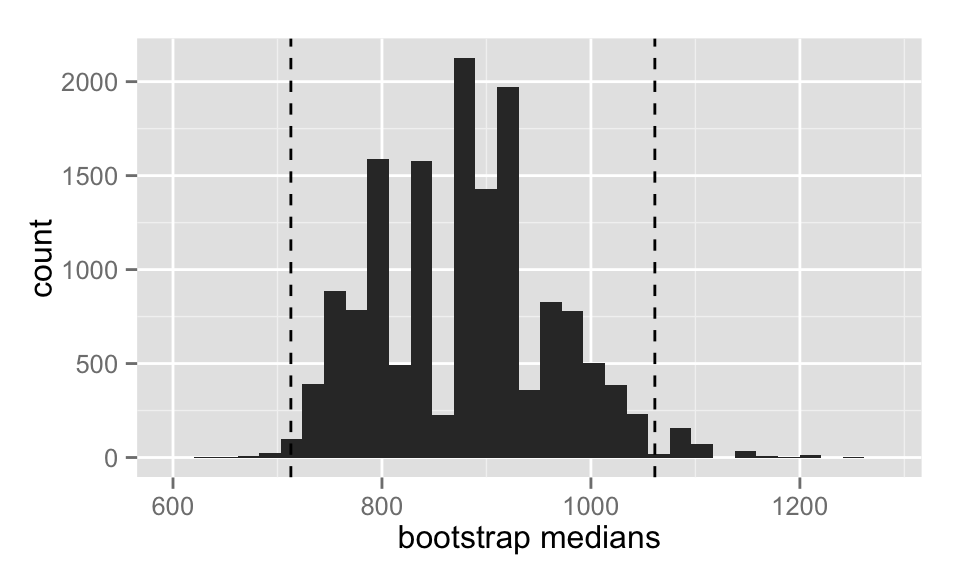

## Bootstrap test for average rent in Durham

Do these data provide convincing evidence that the average rent in Durham for 1+ bedroom apartments is greater than $800?

```r
one_num_test(durham_apts$rent, statistic = mean, null = 800, alt = "greater", seed = 28732)
```

```
## H0: mu = 800
## HA: mu > 800
## Summary stats: n = 20, sample mean = 920.1
## p-value =  0.0251
```

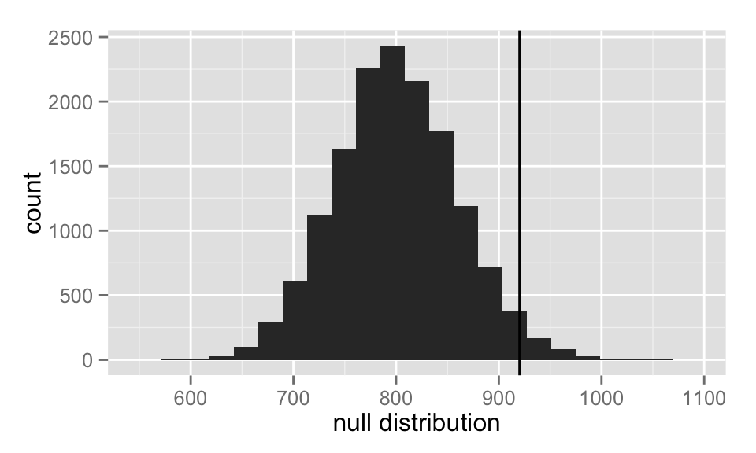

## Other helper functions

For future use…

```r
source("https://stat.duke.edu/courses/Fall15/sta112.01/code/one_cat_boot.R")
source("https://stat.duke.edu/courses/Fall15/sta112.01/code/one_cat_test.R")
```

## Testing for independence

## Is yawning contagious?

Do you think yawning is contagious?

[figure not shown]

[figure not shown]

## Is yawning contagious?

An experiment conducted by the MythBusters tested if a person can be subconsciously influenced into yawning if another person near them yawns.

http://snagplayer.video.dp.discovery.com/614929/snag-it-player.htm?auto=no

## Study description

In this study 50 people were randomly assigned to two groups: 34 to a group where a person near them yawned (treatment) and 16 to a control group where they didn't see someone yawn (control).

```r
table(mb_yawn$group, mb_yawn$outcome)
```

```
##
##             not yawn yawn
##   control         12    4
##   treatment       24   10
```

## Proportion of yawners

```r
addmargins(table(mb_yawn$group, mb_yawn$outcome))
```

```
##
##             not yawn yawn Sum
##   control         12    4  16
##   treatment       24   10  34
##   Sum             36   14  50
```

- Proportion of yawners in the treatment group: \(\frac{10}{34} = 0.2941\)
- Proportion of yawners in the control group: \(\frac{4}{16} = 0.25\)
- Our results match the ones calculated on the MythBusters episode.

Based on the proportions we calculated, do you think yawning is really contagious, i.e. are seeing someone yawn and yawning dependent?

## Two competing claims

- ``There is nothing going on." Yawning and seeing someone yawn are **independent**, yawning is not contagious, observed difference in proportions is simply due to chance. \(\rightarrow\) Null hypothesis
- ``There is something going on." Yawning and seeing someone yawn are **dependent**, yawning is contagious, observed difference in proportions is not due to chance. \(\rightarrow\) Alternative hypothesis

## Simulation setup

1. A regular deck of cards is comprised of 52 cards: 4 aces, 4 of numbers 2-10, 4 jacks, 4 queens, and 4 kings.
2. Take out two aces from the deck of cards and set them aside.
3. The remaining 50 playing cards to represent each participant in the study:
   - 14 face cards (including the 2 aces) represent the people who yawn.
   - 36 non-face cards represent the people who don't yawn.

## Running the simulation

*http://www.dartmouth.edu/~chance/course/topics/winning_number.html*

## Checking for independence

Do the simulation results suggest that yawning is contagious, i.e. does seeing someone yawn and yawning appear to be dependent?

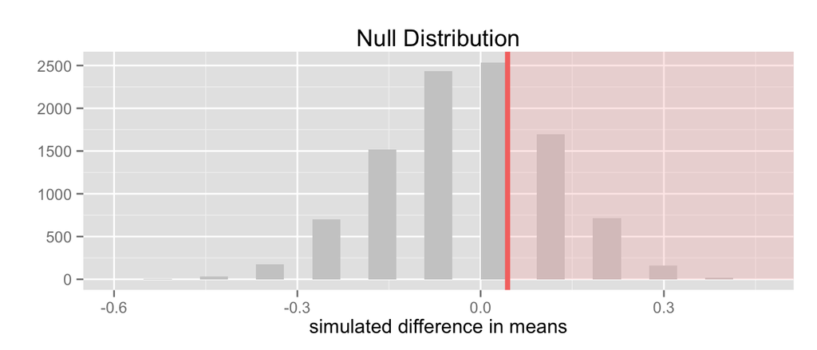

```
## $p_hat_diff
## [1] 0.0441
##
## $p_value
## [1] 0.513
```

Write a function that conducts a randomization test as described above for two categorical variables. Run the function for the yawning dataset. Comminicate with other teams to match your answers for a given seed.